# PASS1A Rat Tissue: – Data Assembly

Alec Steep

20200604

## Setup the Environment

```r
################################################################################
##### Resources and Dependencies ###############################################
################################################################################

# Set the working directory
WD <- '/Volumes/Frishman_4TB/motrpac/20200309_rna-seq_steep'
#setwd(WD)

# Load the dependencies
#source('https://bioconductor.org/biocLite.R')
#BiocManager::install('ImpulseDE2')
#install.packages('tidyverse')

# Load dependencies
pacs...man <- c('tidyverse','GenomicRanges', 'DESeq2','devtools','rafalib','GO.db','vsn','hexbin','ggplot2', 'GenomicFeatures','Biostrings','BSgenome','AnnotationHub','plyr','dplyr', 'org.Rn.eg.db','pheatmap','sva','formula.tools','pathview','biomaRt', 'PROPER','SeqGSEA','purrr','BioInstaller','RColorBrewer','lubridate', 'hms','ggpubr', 'ggrepel','genefilter','qvalue','ggfortify','som', 'vsn','org.Mm.eg.db','VennDiagram','EBImage','reshape2','xtable','kohonen','som','caret','enrichR','gplots','tiff','splines','gam','EnhancedVolcano','mvoutlier','multtest','bigutilsr','bigstatsr','magrittr','ImpulseDE2')
lapply(pacs...man, FUN = function(X) {
        do.call('library', list(X)) })
```

## Load Custom Functions

```r
################################################################################
######################### Functions ############################################
################################################################################

# Set select
select <- dplyr::select
counts <- DESeq2::counts
map <- purrr::map

# Global options
options(dplyr.print_max = 100)

# Source the functions
source(paste0(WD,'/functions/not_in.R'))
source(paste0(WD,'/functions/rat_mouse_ortho.R'))
source(paste0(WD,'/functions/mouse2rat_ortho.R'))
source(paste0(WD,'/functions/lmp.R'))
source(paste0(WD,'/functions/cor_PC_1_6.R'))
source(paste0(WD,'/functions/elbow_finder.R'))
source(paste0(WD,'/functions/cor_outlier2.R'))
```

## Declare Variables

```r
################################################################################
#####     Declare Variables     ################################################
################################################################################
```

#### Section to generate a table of major decisions

```r
# TISSUE: Hypothalamus, Liver, Kidney, Aorta, Adrenal, Brown Adipose, Cortex, Gastrocnemius, Heart, Hippocampus,Lung,Ovaries,PaxGene,Spleen,Testes, White Adipose

# SCN: Hypothalamus (Suprachiasmatic nucleus)
# LIV: Liver
# KID: Kidney
# AOR: Aorta
# SKM: Gastrocnemius
# HAT: Heart
# ADG: Adrenal gland
# BAT: Brown adipose tissue
# WAT: White adipose tissue
# COR: Cortex
# HIP: Hippocampus
# LUNG: Lung
# OVR: Ovaries
# SPL: Spleen
# TES: Testes

# Create the
df_tbl <- data.frame(matrix(ncol = 8, nrow = 0))
names(df_tbl) <- c('Tissue','Tis','Seq_Batch','Misidentified',
                   'Adjusted_Variables','Outliers','Formula')
for(TISSUE in c('Hippocampus')){
        # for(TISSUE in c('Hypothalamus', 'Kidney', 'Aorta', 'Adrenal', 'Brown Adipose', 'Cortex', 'Gastrocnemius', 'Heart', 'Hippocampus','Lung','Ovaries','Spleen', 'White Adipose','Liver','Testes')){
        # Declare Outliers
        if(TISSUE == 'Kidney'){
                TIS <- 'KID'
                MIS_ID_VAR <- c('None')
                MIS_SUS <- c('None')
                MIS_ID <- c('None')
                PRI_VAR <- c('animal.registration.sex')
                FINAL_FORMULA <- formula(paste0('~ ',PRI_VAR[1],
                                                ' + animal.key.anirandgroup'))
                OUTLIERS <- c('None')
        }else if(TISSUE == 'Liver'){
                TIS <- 'LIV'
                MIS_ID_VAR <- c('None')
                MIS_SUS <- c('None')
                MIS_ID <- c('None')
                PRI_VAR <- c('animal.registration.sex')
                OUTLIERS <- c('None')
                FINAL_FORMULA <- formula(paste0('~ ',PRI_VAR[1],
                                                ' + animal.key.anirandgroup'))
        }else if(TISSUE == 'Hypothalamus'){
                TIS <- 'SCN'
                MIS_ID_VAR <- c('animal.registration.sex')
                MIS_SUS <- c('90010015402_SF2','90011015402_SF2')
                MIS_ID <- c('90010015402_SF2','90011015402_SF2')
                PRI_VAR <- c('animal.registration.sex')
                FINAL_FORMULA <- formula(paste0('~ ',PRI_VAR[1],
                                                ' + animal.key.anirandgroup'))
                OUTLIERS <- c('None')
        }else if(TISSUE == 'Aorta'){
                TIS <- 'AOR'
                MIS_ID_VAR <- c('None')
                MIS_SUS <- c('None')
                MIS_ID <- c('None')
                PRI_VAR <- c('None')
                FINAL_FORMULA <- formula(paste0('~ animal.key.anirandgroup'))
                OUTLIERS <- c('90159016502_SN2')
        }else if(TISSUE == 'Gastrocnemius'){
                TIS <- 'SKM'
                MIS_ID_VAR <- c('None')
                MIS_SUS <- c('None')
                MIS_ID <- c('None')
                PRI_VAR <- c('animal.registration.sex')
                FINAL_FORMULA <- formula(paste0('~ ',PRI_VAR[1],
                                                ' + animal.key.anirandgroup'))
                OUTLIERS <- c('None')
        }else if(TISSUE == 'Heart'){
                TIS <- 'HAT'
                MIS_ID_VAR <- c('None')
                MIS_SUS <- c('None')
                MIS_ID <- c('None')
                PRI_VAR <- c('animal.registration.sex')
                FINAL_FORMULA <- formula(paste0('~ ',PRI_VAR[1],
                                                ' + animal.key.anirandgroup'))
                OUTLIERS <- c('90052015802_SN1')
        }else if(TISSUE == 'Adrenal'){
                TIS <- 'ADG'
                MIS_ID_VAR <- c('None')
                MIS_SUS <- c('None')
                MIS_ID <- c('None')
                PRI_VAR <- c('animal.registration.sex')
                FINAL_FORMULA <- formula(paste0('~ ',PRI_VAR[1],
                                                ' + animal.key.anirandgroup'))
                OUTLIERS <- c('None')
        }else if(TISSUE == 'Brown Adipose'){
                TIS <- 'BAT'
                MIS_ID_VAR <- c('animal.registration.sex')
                MIS_SUS <- c('90121016905_SF1','90014016905_SF1','90128016905_SF1','90047016905_SF1','90001016905_SF1',
                             '90018016905_SF1')
                MIS_ID <- c('None')
                PRI_VAR <- c('animal.registration.sex')
                FINAL_FORMULA <- formula(paste0('~ ',PRI_VAR[1],
                                                ' + animal.key.anirandgroup'))
                OUTLIERS <- c('90023016905_SF1','90047016905_SF1','90128016905_SF1')
        }else if(TISSUE == 'White Adipose'){
                TIS <- 'WAT'
                MIS_ID_VAR <- c('animal.registration.sex')
                MIS_SUS <- c('None')
                MIS_ID <- c('None')
                PRI_VAR <- c('animal.registration.sex')
                FINAL_FORMULA <- formula(paste0('~ ',PRI_VAR[1],
                                                ' + animal.key.anirandgroup'))
                OUTLIERS <- c('None')
        }else if(TISSUE == 'Cortex'){
                TIS <- c('COR')
                MIS_ID_VAR <- c('None')
                MIS_SUS <- c('None')
                MIS_ID <- c('None')
                PRI_VAR <- c('animal.registration.sex')
                FINAL_FORMULA <- formula(paste0('~ ',PRI_VAR[1],
                                                ' + animal.key.anirandgroup'))
                OUTLIERS <- c('None')
        }else if(TISSUE == 'Hippocampus'){
                TIS <- c('HIP')
                MIS_ID_VAR <- c('animal.registration.sex')
                MIS_SUS <- c('90115015202_SF2','90041015202_SF2')
                MIS_ID <- c('None')
                PRI_VAR <- c('None')
                FINAL_FORMULA <- formula(paste0('~ animal.key.anirandgroup'))
                OUTLIERS <- c('90040015202_SF2','90115015202_SF2','90041015202_SF2',
                              '90009015202_SF2','90005015202_SF2','90139015202_SF2')
        }else if(TISSUE == 'Lung'){
                TIS <- 'LUNG'
                OUTLIERS <- c('None')
                MIS_ID_VAR <- c('animal.key.batch')
                PRI_VAR <- c('animal.key.batch','animal.registration.sex')
                MIS_SUS <- c('90120016604_SN3', '90146016604_SN3', '90112016604_SN3',
                             '90129016604_SN3', '90124016604_SN3','90114016604_SN3',
                             '90112016604_SN3','90126016604_SN3')
                MIS_ID <- c('None')
                FINAL_FORMULA <- formula(paste0('~ ',PRI_VAR[1],' + ',PRI_VAR[2],
                                                ' + animal.key.anirandgroup'))
        }else if(TISSUE == 'Ovaries'){
                TIS <- c('OVR')
                MIS_ID_VAR <- c('None')
                MIS_SUS <- c('None')
                MIS_ID <- c('None')
                PRI_VAR <- c('None')
                FINAL_FORMULA <- formula(paste0('~ animal.key.anirandgroup'))
                OUTLIERS <- c('None')
        }else if(TISSUE == 'Testes'){
                TIS <- c('TES')
                MIS_ID_VAR <- c('None')
                MIS_SUS <- c('None')
                MIS_ID <- c('None')
                PRI_VAR <- c('None')
                FINAL_FORMULA <- formula(paste0('~ animal.key.anirandgroup'))
                OUTLIERS <- c('90017016302_SN2','90031016302_SN2','90127016302_SN2','90015016302_SN2','90129016302_SN2')
        }else if(TISSUE == 'Spleen'){
                TIS <- 'SPL'
                MIS_ID_VAR <- c('None')
                MIS_SUS <- c('None')
                MIS_ID <- c('None')
                PRI_VAR <- c('animal.registration.sex')
                FINAL_FORMULA <- formula(paste0('~ ',PRI_VAR[1],
                                                ' + animal.key.anirandgroup'))
                OUTLIERS <- c('None')
        }
        # Create the row for the dataframe
        df_r <- data.frame(Tissue = TISSUE,
                           Tis = TIS,
                           Seq_Batch = 'None',
                           Misidentified = MIS_ID,
                           Adjusted_Variance = PRI_VAR,
                           Outliers = OUTLIERS,
                           Formula = as.character(FINAL_FORMULA))
        df_tbl <- rbind(df_tbl,df_r)
}

# Save the decision table
table_file <- paste0(WD,'/data/20200603_rnaseq-tissue-data-assambly-table_steep.txt')
#write.table(df_tbl, file = table_file,sep = '\t',row.names = F,quote = F)
```

#### Final table saved as:

/Volumes/Frishman_4TB/motrpac/20200309_rna-seq_steep/data/20200603_rnaseq-tissue-data-assambly-table_steep.txt

## Take Homes

#### Tissue:

Hippocampus

#### Mis-identified Samples:

None

#### Covariables to Investigate:

None

#### Final Modeling Formula:

~, animal.key.anirandgroup

#### Outlier Samples:

90040015202_SF2, 90115015202_SF2, 90041015202_SF2, 90009015202_SF2, 90005015202_SF2, 90139015202_SF2

## Load & Clean Data

##### Data files to load:

- Count Matrix and Metadata Table from:
  - RNA-Seq from Mt. Sinai
    - 3 sequencing batches & metadata
  - RNA-Seq from Stanford
    - 2 sequencing batches & metadata

```r
################################################################################
#####     Load & Clean Data      ###############################################
################################################################################

# Files last saved in: 20200309_exploration-rna-seq-phase1_steep.R

if(F) {
        # Count matrix
        in_file <- paste0(WD,'/data/20200309_rnaseq-countmatrix-pass1a-stanford-sinai_steep.csv')
        count_data <- read.table(in_file,sep = ',', header = TRUE,row.names = 1,check.names = FALSE)

        # Meatdata table
        in_file <- paste0(WD,'/data/20200309_rnaseq-meta-pass1a-stanford-sinai_steep.txt')
        col_data <- read.table(in_file, header = TRUE, check.names = FALSE, sep = '\t')
        row.names(col_data) <- col_data$sample_key

        # Adjust column objects
        ########################
        # To factors
        factor_cols <- c('labelid',
                         'vial_label',
                         'animal.registration.sex',
                         'animal.key.exlt4',
                         'X2D_barcode',
                         'BID',
                         'Seq_flowcell_lane',
                         'Seq_flowcell_run',
                         'Seq_end_type',
                         'Lib_UMI_cycle_num',
                         'pid',
                         'acute.test.staffid',
                         'acute.test.siteid',
                         'acute.test.versionnbr',
                         'acute.test.contactshock',
                         'animal.familiarization.staffid',
                         'animal.familiarization.siteid',
                         'animal.familiarization.versionnbr',
                         'animal.familiarization.compliant',
                         'animal.key.protocol',
                         'animal.key.agegroup',
                         'animal.key.batch',
                         'animal.key.intervention',
                         'animal.key.sitename',
                         'animal.registration.staffid',
                         'animal.registration.siteid',
                         'animal.registration.versionnbr',
                         'animal.registration.ratid',
                         'animal.registration.batchnumber',
                         'specimen.collection.bloodcomplete',
                         'specimen.collection.bloodtechid',
                         'specimen.collection.uterustype',
                         'specimen.collection.uterustechid',
                         'specimen.collection.deathtype',
                         'specimen.processing.versionnbr',
                         'specimen.processing.siteid',
                         'bid',
                         'specimen.processing.samplenumber',
                         'specimen.processing.techid',
                         'barcode',
                         'shiptositeid',
                         'receivedcas',
                         'receivestatuscas')
        for(fc in factor_cols){
                col_data[[fc]] <- as.factor(col_data[[fc]])
        }

        # To Dates: 03JUL2018
        date_cols <- c('acute.test.d_visit',
                       'acute.test.d_start',
                       'animal.familiarization.d_visit',
                       'animal.familiarization.d_treadmillbegin',
                       'animal.familiarization.d_treadmillcomplete',
                       'animal.registration.d_visit',
                       'animal.registration.d_arrive',
                       'animal.registration.d_reverselight',
                       'specimen.collection.d_visit',
                       'animal.registration.d_birth',
                       'Seq_date')
        for(dc in date_cols){
                col_data[[dc]] <- ymd(col_data[[dc]])
        }

        # From Dates: 2/14/2019
        date_cols <- c('RNA_extr_date',
                       'Lib_prep_date')
        for(dc in date_cols){
                col_data[[dc]] <- mdy(col_data[[dc]])
        }

        # To Times: 10:30:00
        time_cols <- c('acute.test.t_complete',
                       'specimen.collection.t_anesthesia',
                       'specimen.collection.t_bloodstart',
                       'specimen.collection.t_bloodstop',
                       'specimen.collection.t_edtafill',
                       'specimen.collection.uteruscomplete',
                       'specimen.collection.t_uterusstart',
                       'specimen.collection.t_uterusstop',
                       'specimen.collection.t_death',
                       'specimen.processing.t_collection',
                       'specimen.processing.t_edtaspin',
                       'specimen.processing.t_freeze',
                       'acute.test.howlongshock',
                       'acute.test.t_start')
        for(tc in time_cols){
                col_data[[tc]] <- col_data[[tc]] %>% as.character() %>% parse_time() %>% as.numeric()
        }

        # Releveling factors
        col_data$animal.key.anirandgroup <- as.character(col_data$animal.key.anirandgroup)
        col_data$animal.key.anirandgroup <- factor(col_data$animal.key.anirandgroup,
                                                   levels = ec_levels)

        # Create a variable for time post exercise
        col_data <- col_data %>%
                mutate(specimen.collection.t_exercise_hour = case_when(
                        animal.key.anirandgroup == 'Control - IPE' ~ -1,
                        animal.key.anirandgroup == 'Control - 7 hr' ~ 7,
                        animal.key.anirandgroup == 'Exercise - IPE' ~ 0,
                        animal.key.anirandgroup == 'Exercise - 0.5 hr' ~ 0.5,
                        animal.key.anirandgroup == 'Exercise - 1 hr' ~ 1,
                        animal.key.anirandgroup == 'Exercise - 4 hr' ~ 4,
                        animal.key.anirandgroup == 'Exercise - 7 hr' ~ 7,
                        animal.key.anirandgroup == 'Exercise - 24 hr' ~ 24,
                        animal.key.anirandgroup == 'Exercise - 48 hr' ~ 48))

        # Take the absolute value of the square root of seconds post exercise (consider negative numbers)
        # Make sure to Subtract 1 hour (3600s) from 'Control - IPE' groups to account for exercise effect
        col_data <- col_data %>%
                mutate(calculated.variables.deathtime_after_acute =
                               ifelse(animal.key.anirandgroup == 'Control - IPE',
                                      calculated.variables.deathtime_after_acute - 3600,
                                      calculated.variables.deathtime_after_acute))
        col_data <- col_data %>%
                mutate(specimen.collection.t_exercise_hour_sqrt = ifelse(
                        calculated.variables.deathtime_after_acute < 0,
                        (sqrt(abs(calculated.variables.deathtime_after_acute))/60/60)*(-1),
                        (sqrt(abs(calculated.variables.deathtime_after_acute))/60/60)))
        row.names(col_data) <- col_data$sample_key

        # Examine histograms
        col_data %>%
                filter(animal.key.anirandgroup != 'Control - 7 hr') %>%
                ggplot(aes(x=calculated.variables.deathtime_after_acute)) +
                geom_histogram(bins = 68)
        col_data %>%
                filter(animal.key.anirandgroup != 'Control - 7 hr') %>%
                ggplot(aes(x=specimen.collection.t_exercise_hour_sqrt)) +
                geom_histogram(bins = 68)

        # Generate a time-last-fed variable
        col_data <- col_data %>%
                mutate(animal_time_last_fed = case_when(
                        animal.key.anirandgroup %!in% c('Control - 7 hr', 'Exercise - 7 hr') ~ parse_time('8:00'),
                        (animal.key.anirandgroup %in% c('Control - 7 hr') &
                                 animal.registration.sex == 'Male') ~ parse_time('11:50'),
                        (animal.key.anirandgroup %in% c('Control - 7 hr') &
                                 animal.registration.sex == 'Female') ~ parse_time('12:30'),
                        (animal.key.anirandgroup %in% c('Exercise - 7 hr') &
                                 animal.registration.sex == 'Male') ~ parse_time('12:30'),
                        (animal.key.anirandgroup %in% c('Exercise - 7 hr') &
                                 animal.registration.sex == 'Female') ~ parse_time('12:50')) %>% as.numeric())

        # Generate a time-fasted variable
        col_data$calculated.variables.deathtime_after_fed <- (col_data$specimen.collection.t_death - col_data$animal_time_last_fed) %>% as.numeric()

        # Generate a non-zero variable
        # The fraction of non-zero counts (function)
        nonzero <- function(x) sum(x != 0)
        # Non zero counts
        nzc <- apply(count_data,2,nonzero)
        ginic <- apply(count_data,2,reldist::gini)
        # Non zero fraction
        nzf <- nzc/nrow(count_data)
        # Mean gene expresison
        m <- apply(count_data,2,mean)
        # SD gene expression
        sd <- apply(count_data,2,sd)
        # Coefficient of variation
        cv <- sd/m
        # Join the dataframe into meta data
        nz_tis_df <- data.frame('sample_key' = colnames(count_data),
                                'NZF' = nzf,
                                'GINI' = ginic,
                                'CV' = cv)
        col_data <- left_join(col_data, nz_tis_df, by = c('sample_key'))

        # Save data as an R objects
        # ################################################################################
        # To determine object size
        sl <- object.size(count_data)
        print(sl, units = 'auto')
        # Meta Data
        meta_file <- paste0(WD,'/data/20200603_rnaseq-meta-pass1a-stanford-sinai-proc_steep.rds')
        saveRDS(col_data, file = meta_file)

        # Count Data
        count_file <- paste0(WD, '/data/20200603_rnaseq-counts-pass1a-stanford-sinai-processed_steep.rds')
        saveRDS(count_data, file = count_file)
}

meta_file <- paste0(WD,'/data/20200603_rnaseq-meta-pass1a-stanford-sinai-proc_steep.rds')
```

#### Polished metadata saved as:

/Volumes/Frishman_4TB/motrpac/20200309_rna-seq_steep/data/20200603_rnaseq-meta-pass1a-stanford-sinai-proc_steep.rds

```r
count_file <- paste0(WD, '/data/20200603_rnaseq-counts-pass1a-stanford-sinai-processed_steep.rds')
```

#### Polished read counts saved as:

/Volumes/Frishman_4TB/motrpac/20200309_rna-seq_steep/data/20200603_rnaseq-counts-pass1a-stanford-sinai-processed_steep.rds

```r
# Set a vector for Exercise/Control Levels and Colors
ec_levels <- c('Exercise - IPE',
               'Exercise - 0.5 hr',
               'Exercise - 1 hr',
               'Exercise - 4 hr',
               'Exercise - 7 hr',
               'Exercise - 24 hr',
               'Exercise - 48 hr',
               'Control - IPE',
               'Control - 7 hr')
ec_colors <- c('gold',
               'darkgoldenrod1',
               'orange',
               'darkorange',
               'darkorange2',
               'darkorange3',
               'darkorange4',
               'steelblue1',
               'steelblue4')

# Load Metadata and count data as R objects
################################################################################
# Restore the metadata object
meta_file <- paste0(WD,'/data/20200603_rnaseq-meta-pass1a-stanford-sinai-proc_steep.rds')
col_data <- readRDS(file = meta_file)
# Restore the count object
count_file <- paste0(WD, '/data/20200603_rnaseq-counts-pass1a-stanford-sinai-processed_steep.rds')
count_data <- readRDS(file = count_file)
```

#### Retrieve Circadian Genes Associated with Tissue

Data from Supplementary Table 2 from:  
Yan, J., Wang, H., Liu, Y. & Shao, C. Analysis of gene regulatory networks in the mammalian circadian rhythm. PLoS Comput. Biol. 4, (2008).  
Downloaded 20200326 by Alec Steep

## Place Genes in Genomic Ranges

#### Reference Genome and Annotation:

Rnor_6.0 (GCA_000001895.4) assembly from Ensembl database (Release 96)  
Found at: http://uswest.ensembl.org/Rattus_norvegicus/Info/Index.

FASTA: Rattus_norvegicus.Rnor_6.0.dna.toplevel.fa.gz  
ftp://ftp.ensembl.org/pub/release-96/fasta/rattus_norvegicus/dna/Rattus_norvegicus.Rnor_6.0.dna.toplevel.fa.gz

GTF: Rattus_norvegicus.Rnor_6.0.96.gtf.gz  
ftp://ftp.ensembl.org/pub/release-96/gtf/rattus_norvegicus/Rattus_norvegicus.Rnor_6.0.96.gtf.gz

## Annotate Genes by Chromosome

```r
################################################################################
#####     Annotate Genes by Chromosome       ###################################
################################################################################

### Determine which control samples are male and female
# Get the list of genes on the W chromosome

# Construct your own personal galgal5 reference genome annotation
# Construct from gtf file from Ensembl (same file used in mapping)
#ens_gtf <- paste0(WD,'/data/Rattus_norvegicus.Rnor_6.0.96.gtf')
#Rn_TxDb <- makeTxDbFromGFF(ens_gtf,
# format=c('gtf'),
# dataSource='Ensembl_Rattus6_gtf',
# organism='Rattus norvegicus',
# taxonomyId=NA,
# circ_seqs=DEFAULT_CIRC_SEQS,
# chrominfo=NULL,
# miRBaseBuild=NA,
# metadata=NULL)
# Save the Rat Genomic Ranges Object
#gf_file <- paste0(WD,'/data/20200603_Rnor-6.0.96-GRanges_steep.sqlite')
#saveDb(Rn_TxDb, file=gf_file)

# To load the annotation
gf_file <- paste0(WD,'/data/20200603_Rnor-6.0.96-GRanges_steep.sqlite')
Rn_TxDb <- loadDb(gf_file)
# Define Female specific sex genes (X chromosome)
# To examine chromosome names
#seqlevels(Rn_TxDb)[1:23]
# Extract genes as GRanges object, then names
X_genes_gr <- genes(Rn_TxDb, columns = 'TXCHROM', filter = list(tx_chrom=c('X')))
# Collect ensembl gene ids for female specific genes
X_ens_id <- names(X_genes_gr)
# Examine the gene symbols
X_sym <- mapIds(org.Rn.eg.db, names(X_genes_gr), 'SYMBOL', 'ENSEMBL')
# Extract genes as GRanges object, then names
Y_genes_gr <- genes(Rn_TxDb, columns = 'TXCHROM', filter = list(tx_chrom=c('Y')))
# Collect ensembl gene ids for female specific genes
Y_ens_id <- names(Y_genes_gr)
sex_ens_id <- c(X_ens_id,Y_ens_id)
# Examine the gene symbols
Y_sym <- mapIds(org.Rn.eg.db, names(Y_genes_gr), 'SYMBOL', 'ENSEMBL')
```

## Collect Samples of Interest and Normalize

```r
################################################################################
#####     Collect Samples of Interest and Normalize      #######################
################################################################################
if(TISSUE == c('Gastrocnemius_MSSM_1')){
        tod_cols <- col_data %>%
                filter(Tissue == 'Gastrocnemius') %>%
                filter(Seq_batch == 'MSSM_1') %>%
                filter(!is.na(animal.registration.sex))
}else if(TISSUE == c('Gastrocnemius_Stanford_1')){
        tod_cols <- col_data %>%
                filter(Tissue == 'Gastrocnemius') %>%
                filter(Seq_batch == 'Stanford_1') %>%
                filter(!is.na(animal.registration.sex))
}else{
        # Filter Samples (meta)
        tod_cols <- col_data %>%
                filter(Tissue == TISSUE) %>%
                filter(!is.na(animal.registration.sex))
}
rownames(tod_cols) <- tod_cols$sample_key

# Collect samples without NA values in TOD
nona_sams <- tod_cols %>%
        filter(!is.na(specimen.collection.t_death_hour)) %>%
        filter(!is.na(animal.registration.sex)) %>%
        select(sample_key) %>% unlist() %>% as.character()
# Collect tissue specific counts
tod_counts <- count_data[,nona_sams]
```

##### Sanity Check: Ensure that the metadata rownames are identical to count matrix column names

```r
all(rownames(tod_cols) == colnames(tod_counts))
```

```
## [1] TRUE
```

```r
# Create a design formula and load counts and supporting annotation into an S4 object (DESeq infrastructure)
design = ~ 1 # Primary variable needs to be last.
title = paste0('Design: ',as.character(design))
dds1 <- DESeqDataSetFromMatrix(countData = tod_counts,
                               colData = tod_cols,
                               design = design)
# Reasoning from:
#citation('PROPER')
#dds
```

#### We remove genes with an average sequencing depth (across samples) of less than 1

Summary of DESeqDataSet Before Filtering:

```r
dds1
```

```
## class: DESeqDataSet
## dim: 32883 78
## metadata(1): version
## assays(1): counts
## rownames(32883): ENSRNOG00000055633 ENSRNOG00000058846 ...
##   ENSRNOG00000055837 ENSRNOG00000055723
## rowData names(0):
## colnames(78): 90152015202_SF2 90148015202_SF2 ... 90046015202_SF2
##   90043015202_SF2
## colData names(211): vial_label X2D_barcode ... GINI CV
```

```r
zero_n <- dds1[(rowSums(counts(dds1))/ncol(dds1) < 1), ] %>%
        nrow() %>% as.character()
reads_n <- 1
keep <- rowSums(counts(dds1))/ncol(dds1) >= reads_n
dds2 <- dds1[keep,]
```

Summary of counts and annotation data in a DESeqDataSet after filtering

```r
# TODO: Critic from Jun: Here we are removing features that have a low average expression. This may be removing important features that might have zero counts in some samples and higher counts in specific groups. Consider developing an algorithm that will account for features with expression in n or more samples.
dds2
```

```
## class: DESeqDataSet
## dim: 20478 78
## metadata(1): version
## assays(1): counts
## rownames(20478): ENSRNOG00000054582 ENSRNOG00000060629 ...
##   ENSRNOG00000055705 ENSRNOG00000058500
## rowData names(0):
## colnames(78): 90152015202_SF2 90148015202_SF2 ... 90046015202_SF2
##   90043015202_SF2
## colData names(211): vial_label X2D_barcode ... GINI CV
```

```r
filter_n <- nrow(dds1) - nrow(dds2) - as.numeric(zero_n)
filter_p <- filter_n/(nrow(dds1) - as.numeric(zero_n))
total_n <- nrow(dds1) - nrow(dds2)
```

##### Number of Genes Removed:

Number of genes with average counts (across samples) less than 1 is 12405

##### If more stringent filtering thresholds employed:

Removing reads with less than or equal to 1 removes an additional 0 features or removes 0% of the non-zero reads (total of 12405 features removed).

```r
dds <- dds2
```

#### Reads per million for each sample

```r
sort(colSums(assay(dds)))/1e6
```

```
## 90041015202_SF2 90040015202_SF2 90160015202_SF2 90008015202_SF2 90146015202_SF2
##        7.358331       16.057189       21.300313       21.412537       21.999429
## 90031015202_SF2 90005015202_SF2 90150015202_SF2 90029015202_SF2 90048015202_SF2
##       22.149825       22.288019       22.397565       22.405357       22.577129
## 90009015202_SF2 90007015202_SF2 90026015202_SF2 90033015202_SF2 90032015202_SF2
##       22.654996       23.432424       23.686925       23.872550       23.934525
## 90115015202_SF2 90159015202_SF2 90052015202_SF2 90138015202_SF2 90148015202_SF2
##       24.103945       24.120755       24.146808       24.438386       24.479304
## 90128015202_SF2 90053015202_SF2 90037015202_SF2 90047015202_SF2 90011015202_SF2
##       24.548170       24.975544       25.116185       25.328803       25.604873
## 90147015202_SF2 90144015202_SF2 90122015202_SF2 90044015202_SF2 90010015202_SF2
##       25.669819       25.682138       25.702585       25.735891       25.778189
## 90012015202_SF2 90157015202_SF2 90139015202_SF2 90124015202_SF2 90126015202_SF2
##       25.819761       25.847229       25.889449       25.995143       26.036527
## 90142015202_SF2 90038015202_SF2 90127015202_SF2 90013015202_SF2 90050015202_SF2
##       26.099687       26.283089       26.305995       26.359363       26.489860
## 90027015202_SF2 90134015202_SF2 90043015202_SF2 90110015202_SF2 90039015202_SF2
##       26.505062       26.509775       26.707561       26.756252       26.759090
## 90117015202_SF2 90118015202_SF2 90046015202_SF2 90135015202_SF2 90129015202_SF2
##       26.811075       26.911741       27.023057       27.031146       27.225544
## 90034015202_SF2 90121015202_SF2 90143015202_SF2 90028015202_SF2 90120015202_SF2
##       27.284256       27.399131       27.460291       27.492495       27.579533
## 90114015202_SF2 90136015202_SF2 90133015202_SF2 90001015202_SF2 90018015202_SF2
##       27.612254       27.685758       27.999281       28.004626       28.206698
## 90045015202_SF2 90140015202_SF2 90119015202_SF2 90141015202_SF2 90109015202_SF2
##       28.449571       28.533448       28.678887       28.962848       28.998116
## 90042015202_SF2 90156015202_SF2 90145015202_SF2 90020015202_SF2 90152015202_SF2
##       29.543634       29.637306       29.706817       30.377093       30.455402
## 90017015202_SF2 90123015202_SF2 90023015202_SF2 90014015202_SF2 90155015202_SF2
##       30.665964       31.007900       33.006290       35.697668       38.281312
## 90025015202_SF2 90015015202_SF2 90112015202_SF2
##       39.618815       39.890472       40.879388
```

#### Size Factor Estimates (summary across samples):

Size facotrs are generally around 1 (scaled) and calculated using the median and are robust to genes with large read counts

```r
# estimateSizeFactors() gives us a robust estimate in sequencing depth.
dds <- estimateSizeFactors(dds)
summary(sizeFactors(dds))
```

```
##    Min. 1st Qu.  Median    Mean 3rd Qu.    Max.
##  0.2921  0.9564  1.0298  1.0273  1.0810  1.6230
```

#### Transform:

```r
rld <- DESeq2::vst(dds, blind = FALSE)
```

Variance Stabalizing Transform (vst)

```r
# for(n in 1){
#         start_time <- Sys.time()
#         #rld <- DESeq2::rlog(dds)
#         end_time <- Sys.time()
#         print(end_time - start_time)
# }
# This command is redundent, but included for safety
rs <- rowSums(counts(dds))
```

## Early Identification/Removal of Outliers

Certain Tissues (e.g. Hippocampus & Testes) demonstrate obvious outlier samples that disrupt covariant identification and correction (could not be “batch-corrected”); therefore, we exercise an early identification and removal of outliers.

#### Outlier Sample Detection Strategy (PCA-Approach)

###### Samples are plotted across principle components (PCs) with PC values used to calculate distances across multiple dimensions. Distance metrics include: Infinite (median and MAD), Mahalanobis, and Local Outlier Factor (LOF). Samples are classified as outliers by their distances across one or more “high variance” PCs. Often, a threshold of greater than or equal to 6 standard deviations (Tukey) from the mean distances in one or more PC(s) justifies outlier status, however, classification is at the discretion of the analysis. Thresholds are adjusted in consideration of skewed distance distributions and multiple tests. This strategy was adopted from Florian Privé, PhD (https://www.r-bloggers.com/detecting-outlier-samples-in-pca/).

#### Description of Plots

###### Variance by PCs: A plot of the variance explained by PCs. Dashed vertical lines represent the elbow.

###### Samples by Multidimensional Distance (2 plots): Samples are plotted by their Local Outlier Factor (log10) and Mahalanobis Distance (log10). Multivariant distances apply across PCs and the PC (above the elbow in the previous plot) with the maximum infinite distance–unique to each PC–is plotted. Thresholds in red represent a potential outlier detection threshold accounting for skewness and multiple testing. In the PC-annotated plot, samples are labeled if they appear above either threshold.

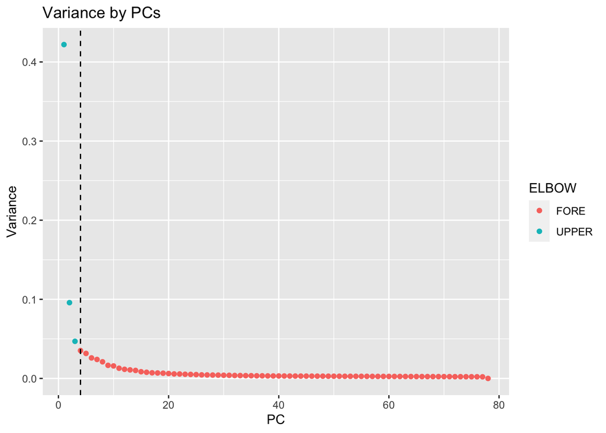

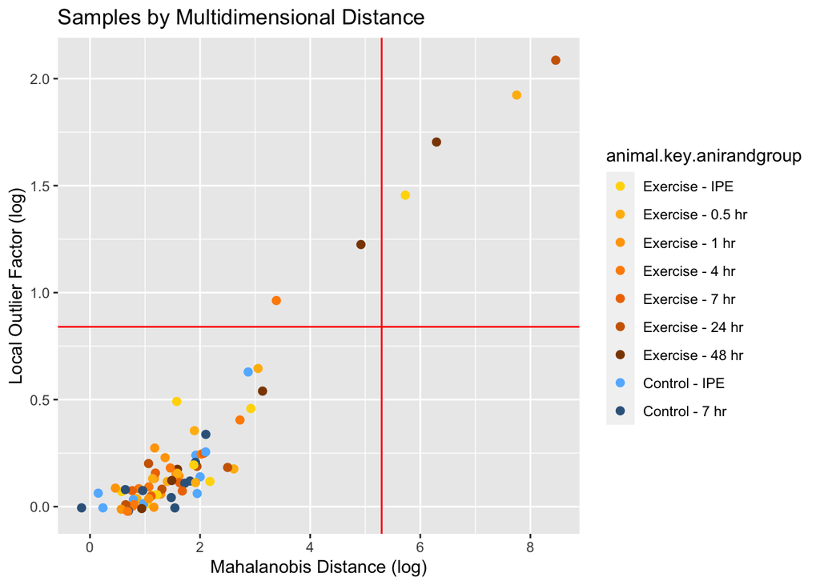

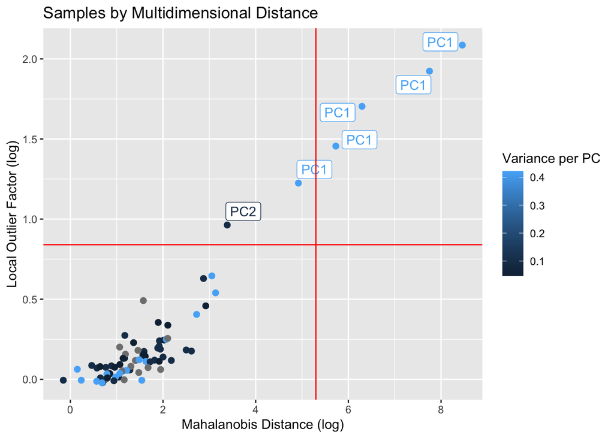

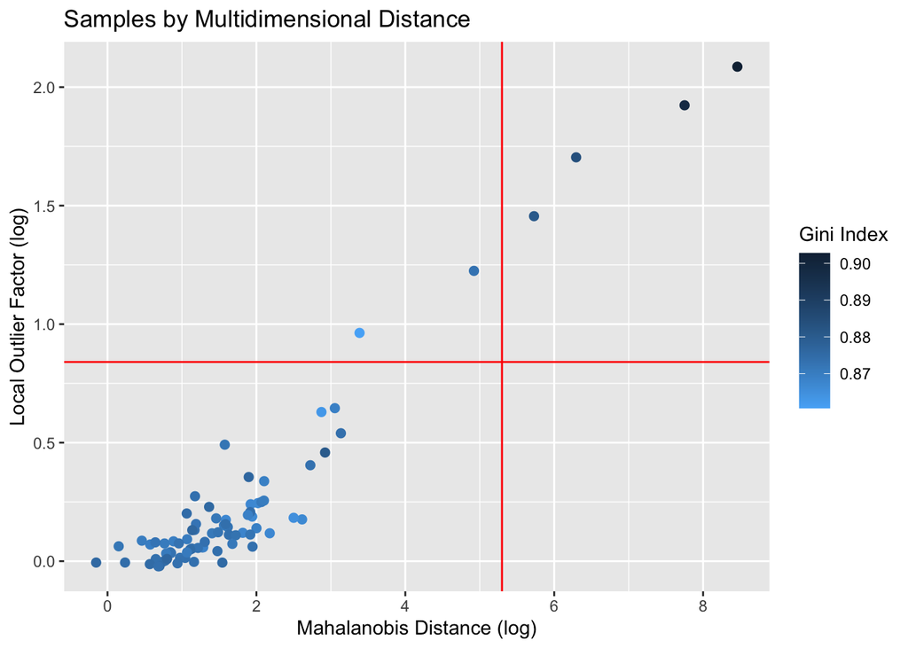

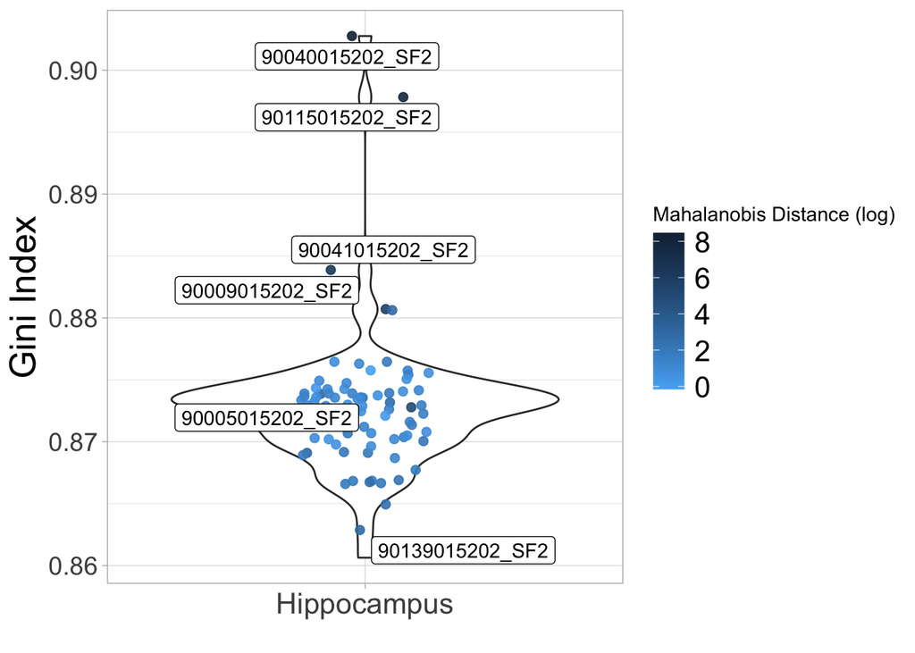

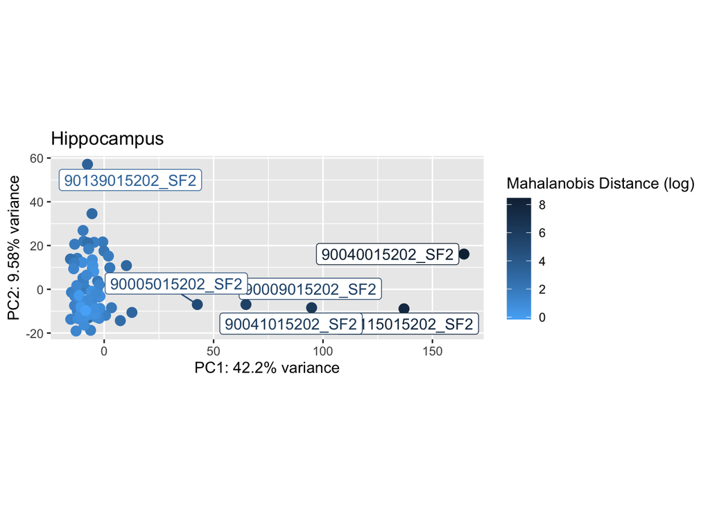

```r
# A few Hippocampus samples demonstrate considerably low Lib_molarity that cannot be compensated for. These samples will be treated as outliers and removed.
if(TISSUE %in% c('Hippocampus','Testes')){
        if(TISSUE == 'Hippocampus'){
                pri_var <- 'Lib_molarity'
        }else if(TISSUE == 'Testes'){
                pri_var <- 'Lib_frag_size..bp.'
                #pri_var <- 'Lib_molarity..nM.'
        }
        pca <- prcomp(t(assay(rld)), scale. = F)
        percentVar <- pca$sdev^2/sum(pca$sdev^2)
        PC <- pca$x %>% as.data.frame()
        PC$sample_key <- row.names(pca$x)
        df_plot <- data.frame(PC = seq_along(pca$sdev^2/sum(pca$sdev^2)),
                              VAR = pca$sdev^2/sum(pca$sdev^2)) %>%
                mutate(ELBOW = ifelse(PC < elbow_finder(PC,VAR)[1], 'UPPER', 'FORE'))
        p <- df_plot %>%
                ggplot(aes(PC,VAR, color = ELBOW)) +
                geom_point() +
                geom_vline(xintercept = elbow_finder(df_plot$PC,df_plot$VAR)[1], linetype='dashed') +
                ggtitle('Variance by PCs') +
                ylab('Variance')
        plot(p)
        PC_meta <- t(pca$x) %>%
                as_tibble() %>%
                mutate(PC = seq_along(pca$sdev^2/sum(pca$sdev^2))) %>%
                mutate(VAR = pca$sdev^2/sum(pca$sdev^2)) %>%
                mutate(ELBOW = ifelse(PC < elbow_finder(PC,VAR)[1], 'UPPER', 'FORE')) %>%
                filter(ELBOW == 'UPPER') %>%
                mutate(PC = as.character(sprintf('PC%d',PC))) %>%
                filter(PC %in% c('PC1','PC2','PC3','PC4'))
        # Reset the pca object
        pca <- prcomp(t(assay(rld)), scale. = F,
                      rank. = elbow_finder(df_plot$PC,df_plot$VAR)[1])
        # Collect Standard Deviations
        pca$sd <- apply(pca$x, 2, function(x) abs(x - median(x)) / mad(x))
        join_meta <- PC_meta[,c('PC','VAR')]
        names(join_meta) <- c('SD_DIST_PC','PC_VAR')
        PC <- PC %>%
                select(
                        c(sprintf('PC%d',1:(elbow_finder(df_plot$PC,df_plot$VAR)[1])),'sample_key')) %>%
                mutate(sample_n = seq_along(PC1)) %>%
                mutate(SD_DIST = apply(pca$x, 2, function(x) abs(x - median(x)) / mad(x)) %>%
                               apply(1, max)) %>%
                mutate(SD_DIST_PC = colnames(pca$sd)[apply(pca$sd,1,which.max)]) %>%
                mutate(TUKEY_OUTLIER = ifelse(SD_DIST > 6, 'Outlier', 'Normal')) %>%
                mutate(MAHALANOBIS_DIST = dist_ogk(pca$x)) %>%
                # Bonferroni correction
                mutate(MAHALANOBIS_FDR = pchisq(MAHALANOBIS_DIST, df = elbow_finder(df_plot$PC,df_plot$VAR)[1], lower.tail = FALSE)*length(MAHALANOBIS_DIST)) %>%
                mutate(MAHALANOBIS_OUTLIER = ifelse(MAHALANOBIS_FDR <= 0.05,
                                                    'Outlier', 'Normal')) %>%
                mutate(LOF = LOF(pca$x, log = F)) %>%
                left_join(y = col_data, by = 'sample_key') %>%
                left_join(y = join_meta, by = 'SD_DIST_PC') %>%
                arrange(dplyr::desc(SD_DIST))
        p <- PC %>%
                mutate(PC_LABEL = ifelse(log(LOF) > tukey_mc_up(log(PC$LOF)) |
                                                 log(MAHALANOBIS_DIST) > tukey_mc_up(log(PC$MAHALANOBIS_DIST)), SD_DIST_PC, '')) %>%
                ggplot(aes(x = log(MAHALANOBIS_DIST), y = log(LOF), color = animal.key.anirandgroup)) +
                geom_point(size = 2) +
                scale_color_manual(values=ec_colors) +
                geom_vline(xintercept = tukey_mc_up(log(PC$MAHALANOBIS_DIST)), color = 'red') +
                geom_hline(yintercept = tukey_mc_up(log(PC$LOF)),  color = 'red') +
                ggtitle('Samples by Multidimensional Distance') +
                ylab('Local Outlier Factor (log)') +
                xlab('Mahalanobis Distance (log)')
        # Samples plotted against 2 multidimension distance metrics--local
        plot(p)
        # Examine the variance from of the PC that is associated with the outlier
        p <- PC %>%
                mutate(PC_LABEL = ifelse(log(LOF) > tukey_mc_up(log(PC$LOF)) |
                                                 log(MAHALANOBIS_DIST) > tukey_mc_up(log(PC$MAHALANOBIS_DIST)), SD_DIST_PC, '')) %>%
                ggplot(aes(x = log(MAHALANOBIS_DIST), y = log(LOF), color = PC_VAR)) +
                geom_point(size = 2) +
                geom_label_repel(aes(label=PC_LABEL)) +
                #geom_label_repel(aes(label=sample_key)) +
                geom_vline(xintercept = tukey_mc_up(log(PC$MAHALANOBIS_DIST)), color = 'red') +
                geom_hline(yintercept = tukey_mc_up(log(PC$LOF)),  color = 'red') +
                ggtitle('Samples by Multidimensional Distance') +
                ylab('Local Outlier Factor (log)') +
                xlab('Mahalanobis Distance (log)') +
                labs(color='Variance per PC')
        plot(p)
        # Visualize the gini index
        p <- PC %>%
                ggplot(aes(x = log(MAHALANOBIS_DIST), y = log(LOF), color = GINI)) +
                geom_point(size = 2) +
                #geom_label_repel(aes(label=sample_key)) +
                geom_vline(xintercept = tukey_mc_up(log(PC$MAHALANOBIS_DIST)), color = 'red') +
                geom_hline(yintercept = tukey_mc_up(log(PC$LOF)),  color = 'red') +
                ggtitle('Samples by Multidimensional Distance') +
                ylab('Local Outlier Factor (log)') +
                xlab('Mahalanobis Distance (log)') +
                labs(color='Gini Index') +
                scale_color_continuous(high = "#132B43", low = "#56B1F7",
                                       name = "Gini Index")
        plot(p)

        PC <- PC %>%
                mutate(OUT_LABEL = ifelse(log(LOF) > tukey_mc_up(log(PC$LOF)) |
                                                 log(MAHALANOBIS_DIST) > tukey_mc_up(log(PC$MAHALANOBIS_DIST)), sample_key, ''))
        # Plot the Gini Index for these samples
        p <- ggplot() +
                geom_violin(data = PC, aes(x = TISSUE, y= GINI)) +
                geom_jitter(data = PC, aes(x = TISSUE, y= GINI,
                                           color = log(MAHALANOBIS_DIST)),
                            height = NULL, width = 0.15,
                            alpha = 0.9, size = 2) +
                geom_label_repel(data = PC, aes(x = TISSUE, y= GINI,label=OUT_LABEL)) +
                xlab("") +
                ylab("Gini Index") +
                theme_light() +
                theme(axis.text.x = element_text(size = 16),
                      axis.text.y = element_text(size = 14),
                      axis.title.y = element_text(size = 20),
                      legend.title = element_text(),
                      legend.text = element_text(size = 16)) +
                scale_color_continuous(high = "#132B43", low = "#56B1F7",
                                       name = "Mahalanobis Distance (log)")
        plot(p)

        p <- PC %>%
                mutate(OUTLIER = ifelse(log(LOF) > tukey_mc_up(log(PC$LOF)) |
                                                log(MAHALANOBIS_DIST) > tukey_mc_up(log(PC$MAHALANOBIS_DIST)), sample_key, '')) %>%
                ggplot(aes(x = PC1, y = PC2, color = log(MAHALANOBIS_DIST))) +
                geom_point(size = 3) +
                coord_equal() +
                geom_label_repel(aes(label=OUTLIER)) +
                xlab(paste0('PC1: ',round(percentVar[1]*100,2),'% variance')) +
                ylab(paste0('PC2: ',round(percentVar[2]*100,2),'% variance')) +
                ggtitle(paste0(TISSUE)) +
                scale_color_continuous(high = "#132B43",low = "#56B1F7",
                                       name = "Mahalanobis Distance (log)")
        plot(p)
        tod_cols <- col_data %>%
                filter(Tissue == TISSUE) %>%
                filter(sample_key %!in% OUTLIERS) %>%
                filter(!is.na(animal.registration.sex))
        rownames(tod_cols) <- tod_cols$sample_key
        nona_sams <- tod_cols %>%
                filter(!is.na(specimen.collection.t_death_hour)) %>%
                filter(!is.na(animal.registration.sex)) %>%
                select(sample_key) %>% unlist() %>% as.character()
        tod_counts <- count_data[,nona_sams]
        all(rownames(tod_cols) == colnames(tod_counts))
        design = ~ 1 # Primary variable needs to be last.
        title = paste0('Design: ',as.character(design))
        dds1 <- DESeqDataSetFromMatrix(countData = tod_counts,
                                       colData = tod_cols,
                                       design = design)
        zero_n <- dds1[(rowSums(counts(dds1))/ncol(dds1) < 1), ] %>%
                nrow() %>% as.character()
        reads_n <- 1
        keep <- rowSums(counts(dds1))/ncol(dds1) >= reads_n
        dds2 <- dds1[keep,]
        dds2
        dds <- dds2
        sort(colSums(assay(dds)))/1e6
        dds <- estimateSizeFactors(dds)
        summary(sizeFactors(dds))
        rld <- DESeq2::vst(dds, blind = FALSE)
        rs <- rowSums(counts(dds))
}
```